# Final

```python
import pandas as pd
import numpy as np

from catboost import CatBoostRegressor
cat = CatBoostRegressor()
import matplotlib.pyplot as plt

from matplotlib import font_manager, rc
import matplotlib

font_name = font_manager.FontProperties(fname="c:/Windows/Fonts/malgun.ttf").get_name()
rc('font', family=font_name)
matplotlib.rcParams['axes.unicode_minus'] = False

from sklearn.metrics import mean_squared_error
from sklearn.model_selection import train_test_split

import seaborn as sns
```

## Train, Test 전처리

```python
data = pd.read_excel("G:\내 드라이브\Github\BigContest_Flood-ZERO/2021 빅콘테스트_데이터분석분야_퓨처스리그_홍수ZERO_댐유입량,강우,수위데이터_210902_update.xlsx" )
```

```python
data.columns = ['홍수사상번호','연', '월', '일', '시간','유입량',
'유역평균강수1','강우A1','강우B1','강우C1','강우D1','수위E1','수위D1',
'유역평균강수2','강우A2','강우B2','강우C2','강우D2','수위E2','수위D2',
'유역평균강수3','강우A3','강우B3','강우C3','강우D3','수위E3','수위D3',
'유역평균강수4','강우A4','강우B4','강우C4','강우D4','수위E4','수위D4',
'유역평균강수5','강우A5','강우B5','강우C5','강우D5','수위E5','수위D5',
'유역평균강수6','강우A6','강우B6','강우C6','강우D6','수위E6','수위D6']
```

```python
train = data.iloc[1:2892]
```

```python
train.head()
```

|  | 홍수사상번호 | 연 | 월 | 일 | 시간 | 유입량 | 유역평균강수1 | 강우A1 | 강우B1 | 강우C1 | ... | 강우D5 | 수위E5 | 수위D5 | 유역평균강수6 | 강우A6 | 강우B6 | 강우C6 | 강우D6 | 수위E6 | 수위D6 |
| --- | --- | --- | --- | --- | --- | --- | --- | --- | --- | --- | --- | --- | --- | --- | --- | --- | --- | --- | --- | --- | --- |
| 1 | 1.0 | 2006.0 | 7.0 | 10.0 | 8.0 | 189.100000 | 6.4 | 7 | 7 | 7 | ... | 8 | 2.54 | 122.66 | 6.4 | 7 | 7 | 8 | 8 | 2.54 | 122.61 |
| 2 | 1.0 | 2006.0 | 7.0 | 10.0 | 9.0 | 216.951962 | 6.3 | 7 | 8 | 7 | ... | 10 | 2.53 | 122.648 | 7.3 | 7 | 8 | 10 | 10 | 2.53 | 122.6 |
| 3 | 1.0 | 2006.0 | 7.0 | 10.0 | 10.0 | 251.424419 | 6.4 | 7 | 9 | 7 | ... | 11 | 2.53 | 122.636 | 8.2 | 7 | 9 | 10 | 11 | 2.53 | 122.59 |
| 4 | 1.0 | 2006.0 | 7.0 | 10.0 | 11.0 | 302.812199 | 7.3 | 7 | 10 | 7 | ... | 14 | 2.53 | 122.62 | 11.3 | 9 | 10 | 15 | 14 | 2.53 | 122.585 |
| 5 | 1.0 | 2006.0 | 7.0 | 10.0 | 12.0 | 384.783406 | 8.2 | 7 | 12 | 8 | ... | 16 | 2.53 | 122.604 | 14.4 | 12 | 12 | 18 | 16 | 2.53 | 122.575 |

5 rows × 48 columns

```python
test = data.iloc[2892:]
test = test.reset_index().drop(['index'],axis =1)
```

```python
test.to_csv('test.csv', index = False)
train.to_csv('train.csv', index = False)
```

```python
train = train.astype(float)
test = test.astype(float)
```

## Submission 전처리

```python
submission = pd.read_excel("G:/내 드라이브/Github/BigContest_Flood-ZERO/2021 빅콘테스트_데이터분석분야_퓨처스리그_홍수ZERO_평가데이터_210803.xlsx" )
```

```python
submission = submission.iloc[1:]
submission = submission.reset_index().drop(['index'],axis =1)
```

```python
유역평균강수 = ['유역평균강수1','유역평균강수2','유역평균강수3','유역평균강수4','유역평균강수5','유역평균강수6']
강우A = ['강우A1','강우A2','강우A3','강우A4','강우A5','강우A6']
강우B = ['강우B1','강우B2','강우B3','강우B4','강우B5','강우B6']
강우C = ['강우C1','강우C2','강우C3','강우C4','강우C5','강우C6']
강우D = ['강우D1','강우D2','강우D3','강우D4','강우D5','강우D6']
수위E = ['수위E1','수위E2','수위E3','수위E4','수위E5','수위E6']
수위D = ['수위D1','수위D2','수위D3','수위D4','수위D5','수위D6']
```

## train 1~25 홍수사상번호별 정규화된 인덱스 추가

```python
X = train.drop('유입량', axis=1)
y = train['유입량']
```

```python
X_1 = X.iloc[:226]
X_2 = X.iloc[226:326]
X_3 = X.iloc[326:407]
X_4 = X.iloc[407:441]
X_5 = X.iloc[441:535]
X_6 = X.iloc[535:581]
X_7 = X.iloc[581:632]
X_8 = X.iloc[632:673]
X_9 = X.iloc[673:741]
X_10 = X.iloc[741:827]
X_11 = X.iloc[827:937]
X_12 = X.iloc[937:1064]
X_13 = X.iloc[1064:1131]
X_14 = X.iloc[1131:1181]
X_15 = X.iloc[1181:1443]
X_16 = X.iloc[1443:1648]
X_17 = X.iloc[1648:1773]
X_18 = X.iloc[1773:1838]
X_19 = X.iloc[1838:1933]
X_20 = X.iloc[1933:2197]
X_21 = X.iloc[2197:2281]
X_22 = X.iloc[2281:2565]
X_23 = X.iloc[2565:2694]
X_24 = X.iloc[2694:2788]
X_25 = X.iloc[2788:2891]
```

```python
dtlists = []
index = pd.DataFrame()
for j in range(1, 26):
    eval('dtlists.append(X_'+str(j)+')')
    dtlists[j-1] = dtlists[j-1].reset_index()
    dtlists[j-1]['인덱스'] = dtlists[j-1].index
    dtlists[j-1]['정규화인덱스'] = dtlists[j-1]['인덱스'] / (len(dtlists[j-1])-1)
    index = pd.concat([index, pd.DataFrame(dtlists[j-1])])

index = index.reset_index()
train['정규화인덱스'] = index['정규화인덱스']
```

## test 26번 홍수사상번호정규화된 인덱스 추가

```python
test['인덱스'] = test.index
test['정규화인덱스'] = test['인덱스'] / (len(test)-1)
```

- 홍수사상번호별로 시간의 흐름에 따라 유입량을 살펴본 결과, 처음과 끝은 유입량이 적고 중간이 가장 높은 경향을 보였다.

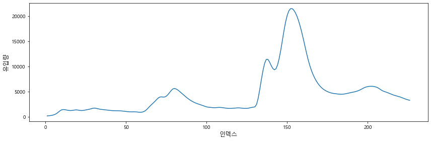

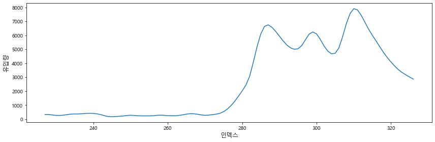

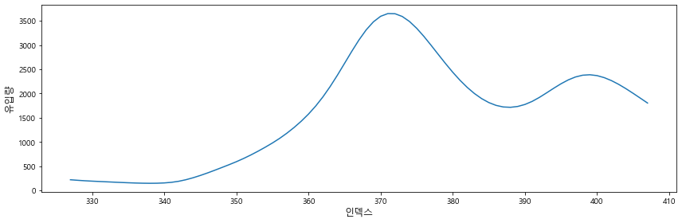

```python
for i in range(1, 4):
    plt.figure(figsize=(12,4))
    eval('plt.plot(train.query(\'홍수사상번호=='+str(i)+'\').index, train.query(\'홍수사상번호=='+str(i)+'\')[\'유입량\'])')
    plt.ylabel('유입량', size=12)
    plt.xlabel('인덱스', size=12)
    plt.tight_layout()
```

- 이러한 경향을 학습시키기 위하여 인덱스 변수를 추가하였다.
- 홍수사상번호별로 행의 갯수가 다르기에 모두 인덱스변수를 정규화하여 사용하였다.

## 점수 예측을 위한 임시 train(홍수사상번호 1 ~ 21) / test(홍수사상번호 22 ~ 25) 분리

```python
X_train, X_test, y_train, y_test = train_test_split(train[['홍수사상번호','연','월','일','시간',*유역평균강수, *강우A, *강우B, *강우C, *강우D, *수위E, *수위D]],
                                                           train['유입량'], test_size=0.2109996, shuffle=False)

Original_train = X_train # 사상번호 1 ~ 21
Original_test = X_test # 사상번호 22 ~ 25
```

## 집단별 점수 비교

```python
X = X.drop(['홍수사상번호', '연', '일', '시간'], axis=1)

X_1_1 = X.drop(X.iloc[:, 8:], axis=1)
X_1_1 = X_1_1.iloc[:226]

X_1_2 = X.drop(X.iloc[:, 1:8], axis=1)
X_1_2 = X_1_2.drop(X.iloc[:, 15:], axis=1)
X_1_2 = X_1_2.iloc[:226]
```

```python
corrs = pd.DataFrame(index=X_1_2.drop(['월'], axis=1).columns, columns=X_1_1.drop(['월'], axis=1).columns)
```

```python
for i in range(7):
    corrs.iloc[:, i] = pd.to_numeric(corrs.iloc[:, i])
```

```python
for i in range(0, 7):
    for j in range(0, 7):
        corrs.iloc[i, j] = np.corrcoef(train.iloc[:, j+6], train.iloc[:, i+13])[0, 1]
```

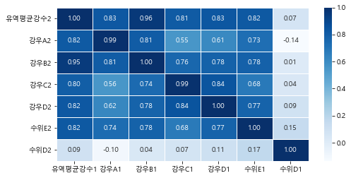

```python
plt.figure(figsize=(8,4))
sns.heatmap(corrs, annot=True, fmt='.2f', linewidths=.5, cmap='Blues')
```

- 집단간에 상관계수를 비교해봤을때, 상관계수가 매우 높다. 이 변수들을 모두 사용했을때, 다중공선성이 있을 것이라 판단하여 집단을 하나만 사용하였다.

### 집단 1

```python
X_train = Original_train[[유역평균강수[0], 강우A[0], 강우B[0], 강우C[0], 강우D[0], 수위E[0], 수위D[0]]]
X_test = Original_test[[유역평균강수[0], 강우A[0], 강우B[0], 강우C[0], 강우D[0], 수위E[0], 수위D[0]]]

categorical_features_indices1 = np.where(X_train.dtypes == np.object)[0]

model = cat
model.fit(X_train, y_train, cat_features = categorical_features_indices1)
```

```
Learning rate set to 0.045201
0:	learn: 2232.4048102	total: 3.58ms	remaining: 3.58s
1:	learn: 2155.9768500	total: 7.24ms	remaining: 3.61s
2:	learn: 2084.5350746	total: 20ms	remaining: 6.63s
3:	learn: 2017.0080663	total: 23.9ms	remaining: 5.96s
4:	learn: 1949.5963061	total: 29.2ms	remaining: 5.82s
5:	learn: 1883.6909623	total: 32.5ms	remaining: 5.38s
6:	learn: 1819.5701151	total: 35.8ms	remaining: 5.07s
7:	learn: 1757.8059345	total: 39.6ms	remaining: 4.91s
8:	learn: 1702.8449271	total: 42.7ms	remaining: 4.7s
9:	learn: 1647.7487454	total: 45.9ms	remaining: 4.54s
10:	learn: 1597.4637707	total: 48.8ms	remaining: 4.39s
11:	learn: 1548.9894047	total: 53.2ms	remaining: 4.38s
12:	learn: 1502.2855266	total: 59.6ms	remaining: 4.53s
13:	learn: 1455.5270984	total: 66.4ms	remaining: 4.68s
14:	learn: 1412.3833131	total: 72.7ms	remaining: 4.77s
15:	learn: 1369.7009470	total: 80.6ms	remaining: 4.95s
16:	learn: 1329.2704868	total: 87.9ms	remaining: 5.08s
17:	learn: 1292.9799407	total: 96.1ms	remaining: 5.24s
18:	learn: 1255.2961936	total: 104ms	remaining: 5.35s
19:	learn: 1220.2432826	total: 108ms	remaining: 5.3s
20:	learn: 1185.4783610	total: 114ms	remaining: 5.32s
21:	learn: 1153.6337677	total: 119ms	remaining: 5.31s
22:	learn: 1124.6407616	total: 124ms	remaining: 5.26s
23:	learn: 1095.9566615	total: 130ms	remaining: 5.28s
24:	learn: 1067.8868056	total: 134ms	remaining: 5.24s
25:	learn: 1041.1123634	total: 140ms	remaining: 5.23s
26:	learn: 1018.4142151	total: 144ms	remaining: 5.19s
27:	learn: 994.2147527	total: 148ms	remaining: 5.14s
28:	learn: 970.4143647	total: 154ms	remaining: 5.16s
29:	learn: 949.2208558	total: 163ms	remaining: 5.27s
30:	learn: 927.5876455	total: 175ms	remaining: 5.48s
31:	learn: 907.6989846	total: 183ms	remaining: 5.52s
32:	learn: 887.3221039	total: 187ms	remaining: 5.48s
33:	learn: 867.9128314	total: 191ms	remaining: 5.44s
34:	learn: 851.0713682	total: 196ms	remaining: 5.4s
35:	learn: 835.2004692	total: 200ms	remaining: 5.36s
36:	learn: 819.1517572	total: 205ms	remaining: 5.33s
37:	learn: 803.9078810	total: 209ms	remaining: 5.29s
38:	learn: 789.9865970	total: 214ms	remaining: 5.26s
```

[output cut: 946 more lines]

```
985:	learn: 95.3450496	total: 4.18s	remaining: 59.3ms
986:	learn: 95.2876679	total: 4.18s	remaining: 55ms
987:	learn: 95.2325117	total: 4.18s	remaining: 50.8ms
988:	learn: 95.1164921	total: 4.19s	remaining: 46.6ms
989:	learn: 95.0696852	total: 4.2s	remaining: 42.4ms
990:	learn: 94.9607932	total: 4.2s	remaining: 38.2ms
991:	learn: 94.9475521	total: 4.21s	remaining: 33.9ms
992:	learn: 94.8689555	total: 4.21s	remaining: 29.7ms
993:	learn: 94.8240496	total: 4.22s	remaining: 25.5ms
994:	learn: 94.6673272	total: 4.22s	remaining: 21.2ms
995:	learn: 94.5733701	total: 4.22s	remaining: 17ms
996:	learn: 94.4859389	total: 4.23s	remaining: 12.7ms
997:	learn: 94.4706187	total: 4.23s	remaining: 8.48ms
998:	learn: 94.3767824	total: 4.24s	remaining: 4.24ms
999:	learn: 94.2001651	total: 4.24s	remaining: 0us
```

```
<catboost.core.CatBoostRegressor at 0x1ef80920580>
```

```python
pred = model.predict(X_test)
```

```python
rmse = (np.sqrt(np.mean(mean_squared_error(y_test, pred))))
rmse
# 1: 774
```

```
759.7370959418506
```

### 집단 2

```python
X_train = Original_train[[유역평균강수[1], 강우A[1], 강우B[1], 강우C[1], 강우D[1], 수위E[1], 수위D[1]]]
X_test = Original_test[[유역평균강수[1], 강우A[1], 강우B[1], 강우C[1], 강우D[1], 수위E[1], 수위D[1]]]

categorical_features_indices1 = np.where(X_train.dtypes == np.object)[0]

model = cat
model.fit(X_train, y_train, cat_features = categorical_features_indices1)
```

```
Learning rate set to 0.045201
0:	learn: 2232.4586127	total: 8.88ms	remaining: 8.87s
1:	learn: 2155.2774971	total: 13.8ms	remaining: 6.88s
2:	learn: 2082.5215974	total: 17ms	remaining: 5.65s
3:	learn: 2015.5617841	total: 21.8ms	remaining: 5.43s
4:	learn: 1947.7622266	total: 26.9ms	remaining: 5.35s
5:	learn: 1882.0306419	total: 30ms	remaining: 4.97s
6:	learn: 1817.9591474	total: 36.2ms	remaining: 5.13s
7:	learn: 1755.8513483	total: 39.2ms	remaining: 4.86s
8:	learn: 1702.1393564	total: 42.4ms	remaining: 4.67s
9:	learn: 1646.5912590	total: 46.3ms	remaining: 4.58s
10:	learn: 1596.1411759	total: 49.4ms	remaining: 4.44s
11:	learn: 1547.4624993	total: 52.6ms	remaining: 4.33s
12:	learn: 1499.2261524	total: 55.7ms	remaining: 4.22s
13:	learn: 1452.2821337	total: 62.2ms	remaining: 4.38s
14:	learn: 1409.6025174	total: 65.4ms	remaining: 4.29s
15:	learn: 1367.0862412	total: 68.5ms	remaining: 4.21s
16:	learn: 1324.2169083	total: 73.9ms	remaining: 4.27s
17:	learn: 1287.6879978	total: 78.2ms	remaining: 4.26s
18:	learn: 1250.8750115	total: 81.4ms	remaining: 4.2s
19:	learn: 1216.8328653	total: 86.5ms	remaining: 4.24s
20:	learn: 1181.6835389	total: 89.7ms	remaining: 4.18s
21:	learn: 1149.8021831	total: 93ms	remaining: 4.13s
22:	learn: 1119.5764682	total: 98.7ms	remaining: 4.19s
23:	learn: 1091.5049408	total: 103ms	remaining: 4.2s
24:	learn: 1063.9189326	total: 115ms	remaining: 4.48s
25:	learn: 1037.0387388	total: 120ms	remaining: 4.49s
26:	learn: 1011.9751693	total: 126ms	remaining: 4.55s
27:	learn: 987.6495738	total: 130ms	remaining: 4.51s
28:	learn: 963.7624810	total: 133ms	remaining: 4.46s
29:	learn: 942.3507014	total: 144ms	remaining: 4.67s
30:	learn: 919.8471436	total: 149ms	remaining: 4.67s
31:	learn: 900.3324797	total: 154ms	remaining: 4.65s
32:	learn: 880.2248793	total: 160ms	remaining: 4.68s
33:	learn: 861.0004083	total: 165ms	remaining: 4.69s
34:	learn: 842.7655899	total: 168ms	remaining: 4.64s
35:	learn: 827.1099245	total: 177ms	remaining: 4.73s
36:	learn: 809.9708506	total: 185ms	remaining: 4.82s
37:	learn: 795.2980916	total: 191ms	remaining: 4.83s
38:	learn: 781.3197878	total: 196ms	remaining: 4.83s
```

[output cut: 946 more lines]

```
985:	learn: 95.7913311	total: 4.8s	remaining: 68.2ms
986:	learn: 95.6430013	total: 4.81s	remaining: 63.4ms
987:	learn: 95.5852265	total: 4.82s	remaining: 58.5ms
988:	learn: 95.5048358	total: 4.82s	remaining: 53.7ms
989:	learn: 95.3888364	total: 4.83s	remaining: 48.8ms
990:	learn: 95.3493622	total: 4.84s	remaining: 43.9ms
991:	learn: 95.2323234	total: 4.84s	remaining: 39.1ms
992:	learn: 95.2243439	total: 4.85s	remaining: 34.2ms
993:	learn: 95.1086941	total: 4.86s	remaining: 29.3ms
994:	learn: 95.0454374	total: 4.87s	remaining: 24.5ms
995:	learn: 94.8831109	total: 4.88s	remaining: 19.6ms
996:	learn: 94.8617583	total: 4.88s	remaining: 14.7ms
997:	learn: 94.8332082	total: 4.89s	remaining: 9.8ms
998:	learn: 94.7083522	total: 4.89s	remaining: 4.9ms
999:	learn: 94.5548353	total: 4.9s	remaining: 0us
```

```
<catboost.core.CatBoostRegressor at 0x1ef80920580>
```

```python
pred = model.predict(X_test)
```

```python
rmse = (np.sqrt(np.mean(mean_squared_error(y_test, pred))))
rmse
# 1: 912
```

```
803.1710778071422
```

### 집단 3

```python
X_train = Original_train[[유역평균강수[2], 강우A[2], 강우B[2], 강우C[2], 강우D[2], 수위E[2], 수위D[2]]]
X_test = Original_test[[유역평균강수[2], 강우A[2], 강우B[2], 강우C[2], 강우D[2], 수위E[2], 수위D[2]]]

categorical_features_indices1 = np.where(X_train.dtypes == np.object)[0]

model = cat
model.fit(X_train, y_train, cat_features = categorical_features_indices1)
```

```
Learning rate set to 0.045201
0:	learn: 2232.4079224	total: 4.52ms	remaining: 4.51s
1:	learn: 2154.9174852	total: 10.4ms	remaining: 5.17s
2:	learn: 2082.7453720	total: 14.9ms	remaining: 4.94s
3:	learn: 2015.9317764	total: 19.2ms	remaining: 4.78s
4:	learn: 1947.0494850	total: 24.2ms	remaining: 4.82s
5:	learn: 1880.1800757	total: 28.7ms	remaining: 4.76s
6:	learn: 1815.4287754	total: 37.5ms	remaining: 5.31s
7:	learn: 1753.4363944	total: 55.4ms	remaining: 6.87s
8:	learn: 1699.9322725	total: 68.3ms	remaining: 7.52s
9:	learn: 1642.6100957	total: 73ms	remaining: 7.23s
10:	learn: 1591.8333310	total: 76.2ms	remaining: 6.85s
11:	learn: 1542.0705166	total: 79.9ms	remaining: 6.58s
12:	learn: 1494.0566627	total: 85.7ms	remaining: 6.51s
13:	learn: 1447.6525534	total: 88.7ms	remaining: 6.25s
14:	learn: 1404.6936791	total: 93.1ms	remaining: 6.11s
15:	learn: 1363.6350610	total: 98.1ms	remaining: 6.03s
16:	learn: 1322.9783016	total: 101ms	remaining: 5.87s
17:	learn: 1284.5026620	total: 105ms	remaining: 5.74s
18:	learn: 1246.7012502	total: 111ms	remaining: 5.75s
19:	learn: 1211.7602803	total: 114ms	remaining: 5.61s
20:	learn: 1176.7752402	total: 119ms	remaining: 5.53s
21:	learn: 1144.6462310	total: 125ms	remaining: 5.56s
22:	learn: 1113.2356218	total: 129ms	remaining: 5.46s
23:	learn: 1084.1266074	total: 132ms	remaining: 5.36s
24:	learn: 1055.7315740	total: 139ms	remaining: 5.41s
25:	learn: 1029.1354830	total: 142ms	remaining: 5.33s
26:	learn: 1003.3052801	total: 145ms	remaining: 5.23s
27:	learn: 979.2211148	total: 152ms	remaining: 5.28s
28:	learn: 955.8339678	total: 156ms	remaining: 5.21s
29:	learn: 933.9686635	total: 160ms	remaining: 5.17s
30:	learn: 912.9374563	total: 165ms	remaining: 5.16s
31:	learn: 893.3462998	total: 178ms	remaining: 5.37s
32:	learn: 874.2650385	total: 182ms	remaining: 5.34s
33:	learn: 854.9477872	total: 191ms	remaining: 5.42s
34:	learn: 838.1126473	total: 197ms	remaining: 5.42s
35:	learn: 822.4598752	total: 209ms	remaining: 5.6s
36:	learn: 805.1348047	total: 218ms	remaining: 5.67s
37:	learn: 790.1245369	total: 224ms	remaining: 5.66s
38:	learn: 776.0747017	total: 235ms	remaining: 5.8s
```

[output cut: 946 more lines]

```
985:	learn: 96.0837417	total: 4.18s	remaining: 59.4ms
986:	learn: 96.0142743	total: 4.19s	remaining: 55.2ms
987:	learn: 95.8907211	total: 4.19s	remaining: 50.9ms
988:	learn: 95.8133609	total: 4.2s	remaining: 46.7ms
989:	learn: 95.7170715	total: 4.2s	remaining: 42.4ms
990:	learn: 95.5820011	total: 4.2s	remaining: 38.2ms
991:	learn: 95.5066558	total: 4.21s	remaining: 33.9ms
992:	learn: 95.3923165	total: 4.21s	remaining: 29.7ms
993:	learn: 95.3716813	total: 4.21s	remaining: 25.4ms
994:	learn: 95.3319332	total: 4.22s	remaining: 21.2ms
995:	learn: 95.2738535	total: 4.22s	remaining: 16.9ms
996:	learn: 95.1857571	total: 4.22s	remaining: 12.7ms
997:	learn: 95.1310828	total: 4.23s	remaining: 8.47ms
998:	learn: 94.9869932	total: 4.23s	remaining: 4.24ms
999:	learn: 94.9649426	total: 4.24s	remaining: 0us
```

```
<catboost.core.CatBoostRegressor at 0x1ef80920580>
```

```python
pred = model.predict(X_test)
```

```python
rmse = (np.sqrt(np.mean(mean_squared_error(y_test, pred))))
rmse
# 1: 985
```

```
792.0017813608149
```

### 집단 4

```python
X_train = Original_train[[유역평균강수[3], 강우A[3], 강우B[3], 강우C[3], 강우D[3], 수위E[3], 수위D[3]]]
X_test = Original_test[[유역평균강수[3], 강우A[3], 강우B[3], 강우C[3], 강우D[3], 수위E[3], 수위D[3]]]

categorical_features_indices1 = np.where(X_train.dtypes == np.object)[0]

model = cat
model.fit(X_train, y_train, cat_features = categorical_features_indices1)
```

```
Learning rate set to 0.045201
0:	learn: 2231.2576677	total: 4.87ms	remaining: 4.87s
1:	learn: 2156.7184233	total: 8.14ms	remaining: 4.06s
2:	learn: 2083.5557864	total: 11.3ms	remaining: 3.74s
3:	learn: 2014.9640479	total: 16ms	remaining: 3.97s
4:	learn: 1944.3493626	total: 19.7ms	remaining: 3.91s
5:	learn: 1880.7269118	total: 22.6ms	remaining: 3.75s
6:	learn: 1815.5517944	total: 27.8ms	remaining: 3.94s
7:	learn: 1753.6037794	total: 31.6ms	remaining: 3.92s
8:	learn: 1696.1211659	total: 35.6ms	remaining: 3.92s
9:	learn: 1639.2272964	total: 41.2ms	remaining: 4.08s
10:	learn: 1588.1508205	total: 44.9ms	remaining: 4.03s
11:	learn: 1538.9326109	total: 48.2ms	remaining: 3.97s
12:	learn: 1490.4591168	total: 53ms	remaining: 4.02s
13:	learn: 1443.1842251	total: 57.7ms	remaining: 4.07s
14:	learn: 1399.7755756	total: 61.4ms	remaining: 4.03s
15:	learn: 1358.2527230	total: 68.7ms	remaining: 4.22s
16:	learn: 1316.7822082	total: 73.2ms	remaining: 4.23s
17:	learn: 1278.1891828	total: 79.1ms	remaining: 4.31s
18:	learn: 1240.3924748	total: 83.7ms	remaining: 4.32s
19:	learn: 1205.9378357	total: 86.9ms	remaining: 4.26s
20:	learn: 1171.8595318	total: 95.3ms	remaining: 4.44s
21:	learn: 1139.4134451	total: 99.1ms	remaining: 4.41s
22:	learn: 1109.0705828	total: 104ms	remaining: 4.42s
23:	learn: 1080.4603164	total: 108ms	remaining: 4.4s
24:	learn: 1052.6388736	total: 111ms	remaining: 4.34s
25:	learn: 1025.5786774	total: 117ms	remaining: 4.39s
26:	learn: 1002.7918855	total: 121ms	remaining: 4.37s
27:	learn: 977.8093427	total: 125ms	remaining: 4.33s
28:	learn: 954.2101104	total: 128ms	remaining: 4.28s
29:	learn: 932.2215580	total: 131ms	remaining: 4.24s
30:	learn: 910.0841639	total: 135ms	remaining: 4.22s
31:	learn: 889.2742390	total: 141ms	remaining: 4.27s
32:	learn: 869.1208400	total: 145ms	remaining: 4.26s
33:	learn: 849.9160697	total: 151ms	remaining: 4.28s
34:	learn: 832.9183713	total: 154ms	remaining: 4.25s
35:	learn: 816.7906300	total: 158ms	remaining: 4.24s
36:	learn: 799.2302797	total: 161ms	remaining: 4.2s
37:	learn: 783.8169265	total: 164ms	remaining: 4.15s
38:	learn: 769.1772967	total: 167ms	remaining: 4.1s
```

[output cut: 946 more lines]

```
985:	learn: 93.9520881	total: 3.93s	remaining: 55.8ms
986:	learn: 93.9189027	total: 3.93s	remaining: 51.8ms
987:	learn: 93.8740957	total: 3.93s	remaining: 47.8ms
988:	learn: 93.8141256	total: 3.94s	remaining: 43.9ms
989:	learn: 93.7966293	total: 3.95s	remaining: 39.9ms
990:	learn: 93.7804013	total: 3.95s	remaining: 35.9ms
991:	learn: 93.7519924	total: 3.96s	remaining: 31.9ms
992:	learn: 93.6254909	total: 3.96s	remaining: 27.9ms
993:	learn: 93.5915125	total: 3.96s	remaining: 23.9ms
994:	learn: 93.4742770	total: 3.97s	remaining: 19.9ms
995:	learn: 93.3032665	total: 3.97s	remaining: 15.9ms
996:	learn: 93.2391817	total: 3.97s	remaining: 12ms
997:	learn: 93.2157548	total: 3.98s	remaining: 7.97ms
998:	learn: 93.1354665	total: 3.98s	remaining: 3.99ms
999:	learn: 92.9751453	total: 3.99s	remaining: 0us
```

```
<catboost.core.CatBoostRegressor at 0x1ef80920580>
```

```python
pred = model.predict(X_test)
```

```python
rmse = (np.sqrt(np.mean(mean_squared_error(y_test, pred))))
rmse
# 1: 769
```

```
704.6983613897916
```

### 집단 5

```python
X_train = Original_train[[유역평균강수[4], 강우A[4], 강우B[4], 강우C[4], 강우D[4], 수위E[4], 수위D[4]]]
X_test = Original_test[[유역평균강수[4], 강우A[4], 강우B[4], 강우C[4], 강우D[4], 수위E[4], 수위D[4]]]

categorical_features_indices1 = np.where(X_train.dtypes == np.object)[0]

model = cat
model.fit(X_train, y_train, cat_features = categorical_features_indices1)
```

```
Learning rate set to 0.045201
0:	learn: 2231.2891020	total: 5.14ms	remaining: 5.13s
1:	learn: 2156.7513299	total: 17.8ms	remaining: 8.88s
2:	learn: 2083.6403040	total: 24ms	remaining: 7.97s
3:	learn: 2015.0485998	total: 27.7ms	remaining: 6.89s
4:	learn: 1944.3786478	total: 33.9ms	remaining: 6.74s
5:	learn: 1880.7464226	total: 37.1ms	remaining: 6.14s
6:	learn: 1815.5287979	total: 40.2ms	remaining: 5.7s
7:	learn: 1753.6046653	total: 51.9ms	remaining: 6.43s
8:	learn: 1696.1496665	total: 56.1ms	remaining: 6.18s
9:	learn: 1638.5163171	total: 60.6ms	remaining: 6s
10:	learn: 1587.7789893	total: 65.5ms	remaining: 5.89s
11:	learn: 1537.9145473	total: 70.8ms	remaining: 5.83s
12:	learn: 1490.1595902	total: 73.9ms	remaining: 5.61s
13:	learn: 1443.2865005	total: 77.1ms	remaining: 5.43s
14:	learn: 1400.0004807	total: 83.3ms	remaining: 5.47s
15:	learn: 1358.5121825	total: 86.5ms	remaining: 5.32s
16:	learn: 1316.8677150	total: 89.8ms	remaining: 5.19s
17:	learn: 1276.9229283	total: 98.3ms	remaining: 5.36s
18:	learn: 1239.7549395	total: 102ms	remaining: 5.29s
19:	learn: 1205.8203507	total: 106ms	remaining: 5.21s
20:	learn: 1171.9101687	total: 110ms	remaining: 5.14s
21:	learn: 1139.4219049	total: 114ms	remaining: 5.07s
22:	learn: 1108.8589707	total: 119ms	remaining: 5.08s
23:	learn: 1078.4460126	total: 131ms	remaining: 5.31s
24:	learn: 1049.5761005	total: 135ms	remaining: 5.27s
25:	learn: 1023.1021047	total: 140ms	remaining: 5.25s
26:	learn: 1000.8315690	total: 144ms	remaining: 5.18s
27:	learn: 976.3412076	total: 147ms	remaining: 5.11s
28:	learn: 953.5665894	total: 154ms	remaining: 5.15s
29:	learn: 931.6972189	total: 158ms	remaining: 5.09s
30:	learn: 909.5288443	total: 161ms	remaining: 5.03s
31:	learn: 888.5712944	total: 164ms	remaining: 4.97s
32:	learn: 868.7329893	total: 179ms	remaining: 5.25s
33:	learn: 849.4079415	total: 186ms	remaining: 5.27s
34:	learn: 831.0530144	total: 196ms	remaining: 5.4s
35:	learn: 813.4815077	total: 202ms	remaining: 5.4s
36:	learn: 796.5416766	total: 206ms	remaining: 5.37s
37:	learn: 781.2255395	total: 210ms	remaining: 5.32s
38:	learn: 766.2317795	total: 216ms	remaining: 5.31s
```

[output cut: 946 more lines]

```
985:	learn: 89.7113131	total: 5.08s	remaining: 72.2ms
986:	learn: 89.6493943	total: 5.09s	remaining: 67ms
987:	learn: 89.5691953	total: 5.09s	remaining: 61.8ms
988:	learn: 89.5024715	total: 5.09s	remaining: 56.7ms
989:	learn: 89.4372722	total: 5.1s	remaining: 51.5ms
990:	learn: 89.3982128	total: 5.1s	remaining: 46.3ms
991:	learn: 89.3604061	total: 5.1s	remaining: 41.2ms
992:	learn: 89.2034327	total: 5.11s	remaining: 36ms
993:	learn: 89.1209121	total: 5.11s	remaining: 30.9ms
994:	learn: 89.0432894	total: 5.11s	remaining: 25.7ms
995:	learn: 88.8476672	total: 5.12s	remaining: 20.6ms
996:	learn: 88.7863461	total: 5.13s	remaining: 15.4ms
997:	learn: 88.6390979	total: 5.13s	remaining: 10.3ms
998:	learn: 88.5832588	total: 5.13s	remaining: 5.14ms
999:	learn: 88.5405769	total: 5.14s	remaining: 0us
```

```
<catboost.core.CatBoostRegressor at 0x1ef80920580>
```

```python
pred = model.predict(X_test)
```

```python
rmse = (np.sqrt(np.mean(mean_squared_error(y_test, pred))))
rmse
# 1: 789
```

```
670.9822236789764
```

### 집단 6

```python
X_train = Original_train[[유역평균강수[5], 강우A[5], 강우B[5], 강우C[5], 강우D[5], 수위E[5], 수위D[5]]]
X_test = Original_test[[유역평균강수[5], 강우A[5], 강우B[5], 강우C[5], 강우D[5], 수위E[5], 수위D[5]]]

categorical_features_indices1 = np.where(X_train.dtypes == np.object)[0]

model = cat
model.fit(X_train, y_train, cat_features = categorical_features_indices1)
```

```
Learning rate set to 0.045201
0:	learn: 2231.1543438	total: 3.93ms	remaining: 3.93s
1:	learn: 2152.9212455	total: 6.43ms	remaining: 3.21s
2:	learn: 2078.5882260	total: 9.32ms	remaining: 3.1s
3:	learn: 2011.5932114	total: 15ms	remaining: 3.73s
4:	learn: 1941.5573855	total: 17.9ms	remaining: 3.56s
5:	learn: 1877.2026974	total: 21.9ms	remaining: 3.63s
6:	learn: 1812.6272151	total: 26.3ms	remaining: 3.73s
7:	learn: 1750.7916542	total: 28.8ms	remaining: 3.58s
8:	learn: 1693.4110235	total: 32.2ms	remaining: 3.54s
9:	learn: 1637.3094828	total: 35ms	remaining: 3.47s
10:	learn: 1586.9094520	total: 40.4ms	remaining: 3.63s
11:	learn: 1537.5658636	total: 43ms	remaining: 3.54s
12:	learn: 1490.2047831	total: 45.8ms	remaining: 3.48s
13:	learn: 1443.1496344	total: 48.3ms	remaining: 3.4s
14:	learn: 1399.8065978	total: 51.5ms	remaining: 3.38s
15:	learn: 1358.1859729	total: 54.4ms	remaining: 3.35s
16:	learn: 1317.0859865	total: 57ms	remaining: 3.29s
17:	learn: 1277.7543879	total: 59.5ms	remaining: 3.25s
18:	learn: 1240.1768510	total: 63.9ms	remaining: 3.3s
19:	learn: 1204.7286488	total: 67ms	remaining: 3.28s
20:	learn: 1169.6749536	total: 69.5ms	remaining: 3.24s
21:	learn: 1137.1178657	total: 72.7ms	remaining: 3.23s
22:	learn: 1106.2625941	total: 76ms	remaining: 3.23s
23:	learn: 1076.5305095	total: 80ms	remaining: 3.25s
24:	learn: 1047.6021794	total: 83ms	remaining: 3.24s
25:	learn: 1021.3689868	total: 90.6ms	remaining: 3.4s
26:	learn: 996.0350601	total: 93.2ms	remaining: 3.36s
27:	learn: 971.1287177	total: 95.9ms	remaining: 3.33s
28:	learn: 948.1421720	total: 99.8ms	remaining: 3.34s
29:	learn: 924.7270697	total: 102ms	remaining: 3.31s
30:	learn: 902.6293679	total: 105ms	remaining: 3.28s
31:	learn: 882.4415089	total: 107ms	remaining: 3.25s
32:	learn: 862.5893322	total: 113ms	remaining: 3.32s
33:	learn: 843.0297159	total: 117ms	remaining: 3.31s
34:	learn: 824.5142372	total: 119ms	remaining: 3.28s
35:	learn: 808.5528773	total: 122ms	remaining: 3.26s
36:	learn: 791.6831760	total: 126ms	remaining: 3.29s
37:	learn: 776.3543740	total: 129ms	remaining: 3.27s
38:	learn: 761.5765490	total: 132ms	remaining: 3.25s
```

[output cut: 946 more lines]

```
985:	learn: 91.5262485	total: 3.55s	remaining: 50.4ms
986:	learn: 91.5059784	total: 3.56s	remaining: 46.8ms
987:	learn: 91.3619247	total: 3.56s	remaining: 43.2ms
988:	learn: 91.2873420	total: 3.56s	remaining: 39.6ms
989:	learn: 91.2655258	total: 3.56s	remaining: 36ms
990:	learn: 91.2239067	total: 3.57s	remaining: 32.4ms
991:	learn: 91.1656486	total: 3.57s	remaining: 28.8ms
992:	learn: 91.1445488	total: 3.57s	remaining: 25.2ms
993:	learn: 91.1242217	total: 3.57s	remaining: 21.6ms
994:	learn: 90.9525415	total: 3.58s	remaining: 18ms
995:	learn: 90.7873267	total: 3.58s	remaining: 14.4ms
996:	learn: 90.7429390	total: 3.58s	remaining: 10.8ms
997:	learn: 90.6795124	total: 3.58s	remaining: 7.19ms
998:	learn: 90.6515627	total: 3.59s	remaining: 3.59ms
999:	learn: 90.6319255	total: 3.59s	remaining: 0us
```

```
<catboost.core.CatBoostRegressor at 0x1ef80920580>
```

```python
pred = model.predict(X_test)
```

```python
rmse = (np.sqrt(np.mean(mean_squared_error(y_test, pred))))
rmse
# 1: 989
```

```
780.2260861941985
```

- 집단 5의 점수가 가장 좋게나와서 집단5만을 사용하였다.

## 수위 D의 유무에 따른 점수 비교

```python
# 집단 1개만을 사용한 상관계수 비교
data = train[['유입량', '유역평균강수1', '강우A1', '강우B1', '강우C1',
       '강우D1', '수위E1', '수위D1']]
data.corr()['유입량']
```

```
유입량        1.000000
유역평균강수1    0.742268
강우A1       0.617424
강우B1       0.739951
강우C1       0.605588
강우D1       0.700568
수위E1       0.903840
수위D1       0.109475
Name: 유입량, dtype: float64
```

- 수위D의 상관계수가 0.1로 매우 낮다

### 수위D 안넣었을 때

```python
X_train = Original_train[[유역평균강수[4],강우A[4], 강우B[4], 강우C[4], 강우D[4], 수위E[4]]]
X_test = Original_test[[유역평균강수[4],강우A[4], 강우B[4], 강우C[4], 강우D[4], 수위E[4]]]

categorical_features_indices1 = np.where(X_train.dtypes == np.object)[0]

model = cat
model.fit(X_train, y_train, cat_features = categorical_features_indices1)
```

```
Learning rate set to 0.045201
0:	learn: 2232.7205806	total: 7.43ms	remaining: 7.42s
1:	learn: 2156.6954020	total: 12.7ms	remaining: 6.33s
2:	learn: 2084.4727968	total: 17ms	remaining: 5.65s
3:	learn: 2013.4086362	total: 21.9ms	remaining: 5.44s
4:	learn: 1945.4178404	total: 28ms	remaining: 5.57s
5:	learn: 1879.8592029	total: 34.5ms	remaining: 5.72s
6:	learn: 1816.7172256	total: 45.8ms	remaining: 6.49s
7:	learn: 1758.6679798	total: 52.7ms	remaining: 6.53s
8:	learn: 1701.0964977	total: 61.7ms	remaining: 6.79s
9:	learn: 1645.9156961	total: 68.9ms	remaining: 6.82s
10:	learn: 1592.7083890	total: 73.9ms	remaining: 6.65s
11:	learn: 1543.7664250	total: 77.5ms	remaining: 6.38s
12:	learn: 1496.8051862	total: 80.6ms	remaining: 6.12s
13:	learn: 1450.8358431	total: 85.4ms	remaining: 6.01s
14:	learn: 1408.8661340	total: 94.7ms	remaining: 6.22s
15:	learn: 1366.6831978	total: 100ms	remaining: 6.18s
16:	learn: 1324.0599389	total: 108ms	remaining: 6.26s
17:	learn: 1283.8813376	total: 111ms	remaining: 6.05s
18:	learn: 1248.3815173	total: 114ms	remaining: 5.87s
19:	learn: 1213.1814877	total: 120ms	remaining: 5.89s
20:	learn: 1180.5084729	total: 125ms	remaining: 5.82s
21:	learn: 1148.9600017	total: 128ms	remaining: 5.67s
22:	learn: 1116.5134296	total: 133ms	remaining: 5.65s
23:	learn: 1086.0131593	total: 136ms	remaining: 5.51s
24:	learn: 1058.0771187	total: 138ms	remaining: 5.39s
25:	learn: 1031.2088839	total: 142ms	remaining: 5.32s
26:	learn: 1005.5365706	total: 145ms	remaining: 5.21s
27:	learn: 981.4902706	total: 147ms	remaining: 5.11s
28:	learn: 958.6723149	total: 150ms	remaining: 5.02s
29:	learn: 936.3937189	total: 153ms	remaining: 4.93s
30:	learn: 914.2725914	total: 158ms	remaining: 4.93s
31:	learn: 892.5246885	total: 161ms	remaining: 4.86s
32:	learn: 872.5026428	total: 163ms	remaining: 4.79s
33:	learn: 854.6787992	total: 166ms	remaining: 4.71s
34:	learn: 838.2724686	total: 169ms	remaining: 4.66s
35:	learn: 822.5767700	total: 173ms	remaining: 4.64s
36:	learn: 807.7816234	total: 181ms	remaining: 4.7s
37:	learn: 791.9864862	total: 185ms	remaining: 4.69s
38:	learn: 777.9700969	total: 193ms	remaining: 4.76s
```

[output cut: 946 more lines]

```
985:	learn: 123.8244859	total: 3.52s	remaining: 50.1ms
986:	learn: 123.7805117	total: 3.53s	remaining: 46.5ms
987:	learn: 123.5167537	total: 3.53s	remaining: 42.9ms
988:	learn: 123.4296274	total: 3.54s	remaining: 39.4ms
989:	learn: 123.3505275	total: 3.54s	remaining: 35.8ms
990:	learn: 123.2844788	total: 3.55s	remaining: 32.2ms
991:	learn: 123.1918049	total: 3.55s	remaining: 28.7ms
992:	learn: 123.0730680	total: 3.56s	remaining: 25.1ms
993:	learn: 122.9702052	total: 3.56s	remaining: 21.5ms
994:	learn: 122.8447684	total: 3.56s	remaining: 17.9ms
995:	learn: 122.6957271	total: 3.57s	remaining: 14.3ms
996:	learn: 122.6188144	total: 3.57s	remaining: 10.7ms
997:	learn: 122.4307184	total: 3.57s	remaining: 7.16ms
998:	learn: 122.3164300	total: 3.58s	remaining: 3.58ms
999:	learn: 122.2699703	total: 3.58s	remaining: 0us
```

```
<catboost.core.CatBoostRegressor at 0x1ef80920580>
```

```python
pred = model.predict(X_test)
```

```python
rmse = (np.sqrt(np.mean(mean_squared_error(y_test, pred))))
rmse
```

```
795.6776213730046
```

### 수위D 넣었을 때

```python
X_train = Original_train[[유역평균강수[4], 강우A[4], 강우B[4], 강우C[4], 강우D[4], 수위D[4], 수위E[4]]]
X_test = Original_test[[유역평균강수[4], 강우A[4], 강우B[4], 강우C[4], 강우D[4], 수위D[4], 수위E[4]]]

categorical_features_indices1 = np.where(X_train.dtypes == np.object)[0]

model = cat
model.fit(X_train, y_train, cat_features = categorical_features_indices1)
```

```
Learning rate set to 0.045201
0:	learn: 2237.5173051	total: 4.55ms	remaining: 4.54s
1:	learn: 2161.2653441	total: 9.89ms	remaining: 4.93s
2:	learn: 2088.3281017	total: 14.2ms	remaining: 4.72s
3:	learn: 2019.6100233	total: 18.6ms	remaining: 4.63s
4:	learn: 1951.9778549	total: 22.6ms	remaining: 4.5s
5:	learn: 1887.8028879	total: 26.9ms	remaining: 4.46s
6:	learn: 1824.4893679	total: 31.6ms	remaining: 4.49s
7:	learn: 1764.3343875	total: 37.2ms	remaining: 4.62s
8:	learn: 1705.8887060	total: 44.2ms	remaining: 4.87s
9:	learn: 1651.9167904	total: 57.9ms	remaining: 5.73s
10:	learn: 1599.2881321	total: 76.1ms	remaining: 6.84s
11:	learn: 1547.2862931	total: 83.5ms	remaining: 6.87s
12:	learn: 1498.5449409	total: 87.8ms	remaining: 6.66s
13:	learn: 1451.5523764	total: 92.1ms	remaining: 6.49s
14:	learn: 1405.4094887	total: 96.2ms	remaining: 6.32s
15:	learn: 1363.8160934	total: 102ms	remaining: 6.26s
16:	learn: 1321.9359842	total: 107ms	remaining: 6.17s
17:	learn: 1282.5894020	total: 113ms	remaining: 6.14s
18:	learn: 1246.7288264	total: 118ms	remaining: 6.11s
19:	learn: 1211.3922812	total: 123ms	remaining: 6s
20:	learn: 1176.7720395	total: 127ms	remaining: 5.91s
21:	learn: 1145.3775154	total: 132ms	remaining: 5.86s
22:	learn: 1114.4918604	total: 136ms	remaining: 5.79s
23:	learn: 1083.0758619	total: 145ms	remaining: 5.9s
24:	learn: 1054.4565359	total: 152ms	remaining: 5.92s
25:	learn: 1027.3036088	total: 156ms	remaining: 5.84s
26:	learn: 999.9415051	total: 161ms	remaining: 5.79s
27:	learn: 974.3957467	total: 166ms	remaining: 5.76s
28:	learn: 952.0419438	total: 170ms	remaining: 5.7s
29:	learn: 929.1236447	total: 174ms	remaining: 5.62s
30:	learn: 906.8825364	total: 179ms	remaining: 5.6s
31:	learn: 885.5898995	total: 184ms	remaining: 5.56s
32:	learn: 866.1932027	total: 190ms	remaining: 5.56s
33:	learn: 848.0011321	total: 194ms	remaining: 5.51s
34:	learn: 830.4921408	total: 198ms	remaining: 5.47s
35:	learn: 814.0089861	total: 203ms	remaining: 5.43s
36:	learn: 797.5535819	total: 207ms	remaining: 5.39s
37:	learn: 781.5205983	total: 213ms	remaining: 5.39s
38:	learn: 767.9149459	total: 217ms	remaining: 5.35s
```

[output cut: 946 more lines]

```
985:	learn: 89.2696355	total: 3.98s	remaining: 56.5ms
986:	learn: 89.1846292	total: 3.98s	remaining: 52.4ms
987:	learn: 89.1348847	total: 3.98s	remaining: 48.4ms
988:	learn: 88.9365619	total: 3.98s	remaining: 44.3ms
989:	learn: 88.8579139	total: 3.99s	remaining: 40.3ms
990:	learn: 88.8009758	total: 3.99s	remaining: 36.2ms
991:	learn: 88.7198718	total: 3.99s	remaining: 32.2ms
992:	learn: 88.5323126	total: 4s	remaining: 28.2ms
993:	learn: 88.4493667	total: 4s	remaining: 24.1ms
994:	learn: 88.3123215	total: 4s	remaining: 20.1ms
995:	learn: 88.1611360	total: 4s	remaining: 16.1ms
996:	learn: 88.1041252	total: 4.01s	remaining: 12.1ms
997:	learn: 87.9939764	total: 4.01s	remaining: 8.04ms
998:	learn: 87.9457055	total: 4.01s	remaining: 4.02ms
999:	learn: 87.8506231	total: 4.02s	remaining: 0us
```

```
<catboost.core.CatBoostRegressor at 0x1ef80920580>
```

```python
pred = model.predict(X_test)
```

```python
rmse = (np.sqrt(np.mean(mean_squared_error(y_test, pred))))
rmse
```

```
648.5832381659743
```

- 수위D를 넣는게 더 좋게 나와서 수위D를 그대로 사용하였다.

# predict

```python
X_train = train[['정규화인덱스',유역평균강수[4],강우A[4], 강우B[4], 강우C[4], 강우D[4],수위D[4], 수위E[4]]]
y_train = train['유입량']

model = cat
model.fit(X_train, y_train)
```

```
Learning rate set to 0.047148
0:	learn: 2101.7381149	total: 163ms	remaining: 2m 42s
1:	learn: 2025.3190218	total: 175ms	remaining: 1m 27s
2:	learn: 1954.4508447	total: 178ms	remaining: 59s
3:	learn: 1884.3282017	total: 180ms	remaining: 44.9s
4:	learn: 1816.8007221	total: 184ms	remaining: 36.7s
5:	learn: 1754.1349168	total: 187ms	remaining: 31s
6:	learn: 1694.1216007	total: 190ms	remaining: 26.9s
7:	learn: 1638.4006958	total: 192ms	remaining: 23.9s
8:	learn: 1582.7920208	total: 197ms	remaining: 21.6s
9:	learn: 1528.9722481	total: 199ms	remaining: 19.7s
10:	learn: 1478.7273537	total: 202ms	remaining: 18.2s
11:	learn: 1430.4881827	total: 205ms	remaining: 16.9s
12:	learn: 1386.1250101	total: 207ms	remaining: 15.7s
13:	learn: 1339.9056956	total: 210ms	remaining: 14.8s
14:	learn: 1295.7853993	total: 213ms	remaining: 14s
15:	learn: 1254.2817947	total: 215ms	remaining: 13.2s
16:	learn: 1214.6277426	total: 218ms	remaining: 12.6s
17:	learn: 1176.2222563	total: 222ms	remaining: 12.1s
18:	learn: 1140.2323925	total: 225ms	remaining: 11.6s
19:	learn: 1105.7199468	total: 228ms	remaining: 11.2s
20:	learn: 1073.7965961	total: 230ms	remaining: 10.7s
21:	learn: 1041.4675664	total: 234ms	remaining: 10.4s
22:	learn: 1013.2040950	total: 237ms	remaining: 10.1s
23:	learn: 984.1614485	total: 239ms	remaining: 9.73s
24:	learn: 958.4204185	total: 242ms	remaining: 9.44s
25:	learn: 933.3395769	total: 245ms	remaining: 9.17s
26:	learn: 909.5551699	total: 248ms	remaining: 8.93s
27:	learn: 886.3767584	total: 251ms	remaining: 8.7s
28:	learn: 863.9943176	total: 253ms	remaining: 8.48s
29:	learn: 842.7610389	total: 256ms	remaining: 8.28s
30:	learn: 823.4558490	total: 260ms	remaining: 8.11s
31:	learn: 802.0848505	total: 263ms	remaining: 7.95s
32:	learn: 783.8372496	total: 265ms	remaining: 7.78s
33:	learn: 766.4730975	total: 268ms	remaining: 7.61s
34:	learn: 749.2006805	total: 272ms	remaining: 7.5s
35:	learn: 733.1263652	total: 275ms	remaining: 7.38s
36:	learn: 718.0018419	total: 278ms	remaining: 7.24s
37:	learn: 702.4816137	total: 281ms	remaining: 7.11s
38:	learn: 688.7871205	total: 284ms	remaining: 7s
```

[output cut: 946 more lines]

```
985:	learn: 80.7311680	total: 3.97s	remaining: 56.4ms
986:	learn: 80.6714368	total: 3.97s	remaining: 52.3ms
987:	learn: 80.6110824	total: 3.98s	remaining: 48.3ms
988:	learn: 80.5718713	total: 3.98s	remaining: 44.2ms
989:	learn: 80.4457753	total: 3.98s	remaining: 40.2ms
990:	learn: 80.3980633	total: 3.98s	remaining: 36.2ms
991:	learn: 80.3470216	total: 3.99s	remaining: 32.2ms
992:	learn: 80.2646536	total: 3.99s	remaining: 28.1ms
993:	learn: 80.1908194	total: 3.99s	remaining: 24.1ms
994:	learn: 80.1623617	total: 4s	remaining: 20.1ms
995:	learn: 80.0482095	total: 4s	remaining: 16.1ms
996:	learn: 80.0128963	total: 4s	remaining: 12ms
997:	learn: 79.9325144	total: 4.01s	remaining: 8.03ms
998:	learn: 79.8663765	total: 4.01s	remaining: 4.01ms
999:	learn: 79.7385998	total: 4.01s	remaining: 0us
```

```
<catboost.core.CatBoostRegressor at 0x1efd597d730>
```

```python
pred = model.predict(test)
```

```python
submission['유입량'] = pred
```

```python
submission
```

|  | 홍수사상번호 | 연 | 월 | 일 | 시간 | 유입량 |
| --- | --- | --- | --- | --- | --- | --- |
| 0 | 26.0 | 2018.0 | 7.0 | 1.0 | 6.0 | 164.076134 |
| 1 | 26.0 | 2018.0 | 7.0 | 1.0 | 7.0 | 184.382132 |
| 2 | 26.0 | 2018.0 | 7.0 | 1.0 | 8.0 | 257.309975 |
| 3 | 26.0 | 2018.0 | 7.0 | 1.0 | 9.0 | 477.307772 |
| 4 | 26.0 | 2018.0 | 7.0 | 1.0 | 10.0 | 657.967668 |
| ... | ... | ... | ... | ... | ... | ... |
| 155 | 26.0 | 2018.0 | 7.0 | 7.0 | 17.0 | 513.359424 |
| 156 | 26.0 | 2018.0 | 7.0 | 7.0 | 18.0 | 513.046559 |
| 157 | 26.0 | 2018.0 | 7.0 | 7.0 | 19.0 | 508.632696 |
| 158 | 26.0 | 2018.0 | 7.0 | 7.0 | 20.0 | 508.632696 |
| 159 | 26.0 | 2018.0 | 7.0 | 7.0 | 21.0 | 508.632696 |

160 rows × 6 columns

```python
submission.to_csv('submission.csv', index = False)
```